# Using the sprintr package

## `cv.sprinter` output

The output of `cv.sprinter` is a `S3` object. The most interesting information is `fit_cv$compact`, which is a matrix of three columns. The first two columns show the indices pairs of all variables finally selected by cross-validation, and the last column is the coefficient estimate corresponding to those selected variables.

```r
fit_cv$compact
```

```
#>       index_1 index_2   coefficient
#>  [1,]       0       1  1.3627135262
#>  [2,]       0       2 -1.8941582052
#>  [3,]       0       3  0.1050959648
#>  [4,]       0       4 -0.4092385412
#>  [5,]       0      21  0.0007039331
#>  [6,]       0      25 -0.0838433007
#>  [7,]       0      26 -0.0499478617
#>  [8,]       0      31 -0.0297285465
#>  [9,]       0      34 -0.0878596104
#> [10,]       0      35  0.0412542636
#> [11,]       0      38 -0.0415217706
#> [12,]       0      39 -0.1453470347
#> [13,]       0      43  0.0642984181
#> [14,]       0      44  0.1203193907
#> [15,]       0      51 -0.0126056316
#> [16,]       0      64  0.0196750028
#> [17,]       0      65 -0.2296652640
#> [18,]       0      66 -0.0175774607
#> [19,]       0      69  0.0073273880
#> [20,]       0      76  0.1071258137
#> [21,]       0      78 -0.0136436397
#> [22,]       0      87 -0.0550568118
#> [23,]       0      91  0.0885291261
#> [24,]       0      99  0.2078193532
#> [25,]       0     100  0.0225545973
#> [26,]       4       5 -4.0211027225
#> [27,]       1       3  2.4013600490
#> [28,]       4      96  0.0890808049
#> [29,]      29      95 -0.1008666063
```

## Summarizing `cv.sprinter` output by `print` and `plot`

Associated with the output of `cv.sprinter` are the `print` and `plot` functions. `print` functions can be used to the summary of the cross-validation process, indicating information such as the best number of candidate interactions in Step 2, and the validation error mean/standard errors, number of non-zero main effects/interactions for the Step-3 tuning parameter selected by `min` rule and `1se` rule.

```r
print(fit_cv)
```

```
#>
#> Call:  cv.sprinter(x = x, y = y, square = FALSE, n_num_keep = 5, nlam = 100,      lam_min_ratio = 0.01)
#>
#> Best number of candidate interactions in Step 2: 7
#>
#>      lambda mean(vali-err) se(vali-err) #nonzero-main #nonzero-inter
#> min 0.09291          4.364       0.8519            25              4
#> 1se 1.25700          5.296       1.2940             2              2
```

The `plot` function for the output of `cv.sprinter` shows the validation error across different folds as a function of Step-3 tuning parameters (for a fixed value of Step-2 tuning parameter chosen by cross-validation). The top of the plot shows the number of nonzero main effects / nonzero interactions corresponding (in orange) to a value of Step-3 tuning parameters.

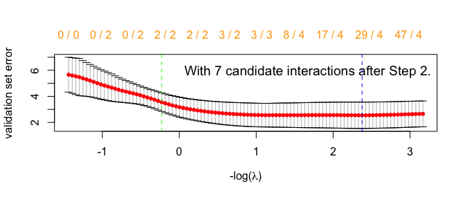

```r
plot(fit_cv)
```

The blue vertical line shows the Step-3 tuning parameter selected by `min` rule, and the green vertical line shows the Step-3 tuning parameter selected by `1se` rule.

# Prediction

The `predict` function is defined for both the object returned by `sprinter` and `cv.sprinter` that computes the prediction for a new data matrix of main effects:

```r
newdata <- matrix(rnorm(20 * p), nrow = 20, ncol = p)
pred <- predict(fit, newdata = newdata)
```

The prediction for `sprinter` object computes the prediction at `newdata` for all the (Step-2, Step-3) tuning parameter pairs, and the prediction for `cv.sprinter` object just computes the prediction at `newdata` for the best tuning parameter pairs selected by cross-validation.

```r
pred_cv <- predict(fit_cv, newdata = newdata)
```

# Support for other response families